# Cambridge Traffic

This document explores traffic accidents in Cambridge, MA from 2010 to 2013. We want to see if there are any discernible patterns in the number of accidents.

First we have to load the data. The data was originally exported from https://data.cambridgema.gov/Public-Safety/Accident-Map-2010-2013/4tke-xhvq to a csv format and then loaded into R. We should also load some of the libraries required.

```r
setwd("~/Documents/Cambridge Traffic Data")
df = read.csv("ACCIDENT-2010-2013.csv", header=TRUE)
```

```r
library(dplyr)
library(ggplot2)
require(ggplot2)
require(sandwich)
require(msm)
```

Next we can do some initial exploratory analysis to see what the dataset contains.

```r
str(df)
```

```
## 'data.frame':    6340 obs. of  12 variables:
##  $ Crash.Number : int  24029 24555 24967 29404 23638 23639 23640 23641 25270 23642 ...
##  $ Date.Time    : Factor w/ 6220 levels "01/01/2010 01:50:59 AM",..: 1684 3575 5072 3313 1 2 3 4 5 26 ...
##  $ Day.Of.Week  : Factor w/ 9 levels "","Friday","Monday",..: 4 3 4 7 2 2 2 2 4 4 ...
##  $ Object.1     : Factor w/ 13 levels "","Auto","Bicycle",..: 2 2 11 2 2 11 2 2 2 12 ...
##  $ Object.2     : Factor w/ 15 levels "","Auto","Bicycle",..: 5 2 3 2 2 2 10 10 10 5 ...
##  $ Street.Number: Factor w/ 770 levels "","0","1","1-25",..: 1 1 1 1 1 1 21 1 474 1 ...
##  $ Steet.Name   : Factor w/ 458 levels "","Aberdeen Ct",..: 1 324 1 155 285 68 102 442 274 271 ...
##  $ Cross.Street : Factor w/ 472 levels "","Aberdeen Ct",..: 1 1 1 1 366 382 1 222 1 352 ...
##  $ Location     : Factor w/ 3268 levels "  &  Cambridge, MA",..: 1 961 1 427 852 238 1437 1299 2511 718 ...
##  $ Latitude     : num  0 0 0 0 42.4 ...
##  $ Longitude    : num  0 0 0 0 -71.1 ...
##  $ Coordinates  : Factor w/ 2684 levels "(0, 0)","(42.353438, -71.107141)",..: 1 1 1 1 2488 1131 826 440 245 144 ...
```

```r
head(df)
```

```
##   Crash.Number              Date.Time Day.Of.Week Object.1     Object.2
## 1        24029 04/10/2010 09:39:00 AM    Saturday     Auto Fixed Object
## 2        24555 08/02/2010 11:55:59 PM      Monday     Auto         Auto
## 3        24967 10/23/2010 12:53:59 PM    Saturday     Taxi      Bicycle
## 4        29404 07/16/2013 12:59:59 PM     Tuesday     Auto         Auto
## 5        23638 01/01/2010 01:50:59 AM      Friday     Auto         Auto
## 6        23639 01/01/2010 02:04:59 AM      Friday     Taxi         Auto
##   Street.Number        Steet.Name Cross.Street
## 1
## 2                      OXFORD AVE
## 3
## 4                        FIRST ST
## 5               Massachusetts Ave   Rindge Ave
## 6                    Cambridge St SCIARAPPA ST
##                                        Location Latitude Longitude
## 1                              &  Cambridge, MA  0.00000   0.00000
## 2                   OXFORD AVE &  Cambridge, MA  0.00000   0.00000
## 3                              &  Cambridge, MA  0.00000   0.00000
## 4                     FIRST ST &  Cambridge, MA  0.00000   0.00000
## 5  Massachusetts Ave & Rindge Ave Cambridge, MA 42.39261 -71.12487
## 6     Cambridge St & SCIARAPPA ST Cambridge, MA 42.37123 -71.08149
##               Coordinates
## 1                  (0, 0)
## 2                  (0, 0)
## 3                  (0, 0)
## 4                  (0, 0)
## 5 (42.392615, -71.124874)
## 6 (42.371233, -71.081493)
```

We won’t be mapping the data today, but we can try to see if there are any patterns for the accidents based on the day of the week or time of day.

First let’s check out a bar plot for the days of the week:

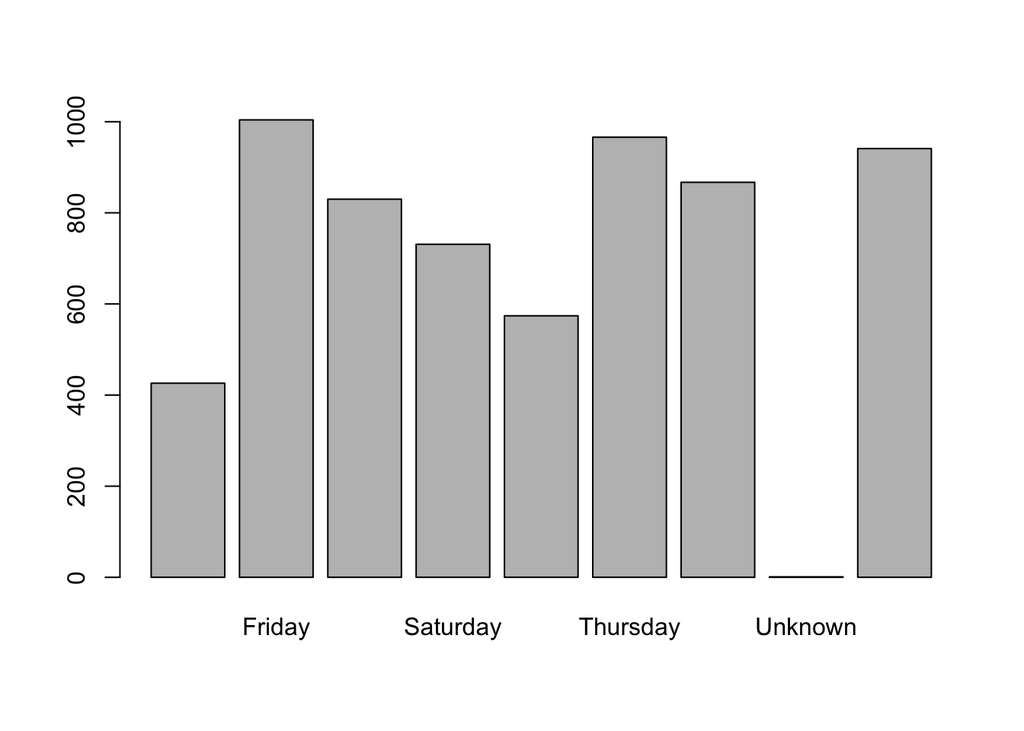

```r
barplot(table(df$Day.Of.Week))
```

This shows us that not all of the days were coded. But there is a time stamp for each event we can use to code the days ourselves. We can use R time formatting to pull out the day of the week and the time of each crash.

```r
#reformatting the time stamp into R time codes
times <- as.POSIXct(df$Date.Time, format='%m/%d/%Y %I:%M:%S %p')

#getting the weekday of the crashes
weekday <- weekdays(as.Date(times))

#getting the hour of the crashes
hours <- format(times, format='%H')

#getting the days of the crashes
days <- format(times, format='%m/%d/%Y')

#adding our new columns to the dataframe for analysis
df$days <- days
df$hours <- hours
df$weekday <- weekday
str(df)
```

```
## 'data.frame':    6340 obs. of  15 variables:
##  $ Crash.Number : int  24029 24555 24967 29404 23638 23639 23640 23641 25270 23642 ...
##  $ Date.Time    : Factor w/ 6220 levels "01/01/2010 01:50:59 AM",..: 1684 3575 5072 3313 1 2 3 4 5 26 ...
##  $ Day.Of.Week  : Factor w/ 9 levels "","Friday","Monday",..: 4 3 4 7 2 2 2 2 4 4 ...
##  $ Object.1     : Factor w/ 13 levels "","Auto","Bicycle",..: 2 2 11 2 2 11 2 2 2 12 ...
##  $ Object.2     : Factor w/ 15 levels "","Auto","Bicycle",..: 5 2 3 2 2 2 10 10 10 5 ...
##  $ Street.Number: Factor w/ 770 levels "","0","1","1-25",..: 1 1 1 1 1 1 21 1 474 1 ...
##  $ Steet.Name   : Factor w/ 458 levels "","Aberdeen Ct",..: 1 324 1 155 285 68 102 442 274 271 ...
##  $ Cross.Street : Factor w/ 472 levels "","Aberdeen Ct",..: 1 1 1 1 366 382 1 222 1 352 ...
##  $ Location     : Factor w/ 3268 levels "  &  Cambridge, MA",..: 1 961 1 427 852 238 1437 1299 2511 718 ...
##  $ Latitude     : num  0 0 0 0 42.4 ...
##  $ Longitude    : num  0 0 0 0 -71.1 ...
##  $ Coordinates  : Factor w/ 2684 levels "(0, 0)","(42.353438, -71.107141)",..: 1 1 1 1 2488 1131 826 440 245 144 ...
##  $ days         : chr  "04/10/2010" "08/02/2010" "10/23/2010" "07/16/2013" ...
##  $ hours        : chr  "09" "23" "12" "12" ...
##  $ weekday      : chr  "Saturday" "Tuesday" "Saturday" "Tuesday" ...
```

We will have to convert the weekday and hour variables to factors so they can be used more easily in the analysis.

```r
#converting some columns to factors
df$weekday <- factor(df$weekday, levels=c("Monday", "Tuesday", "Wednesday",
                                          "Thursday", "Friday", "Saturday", "Sunday"), ordered=T)
df$hour <- factor(df$hour)
```

Now let’s visualize the crashes by day and hour. We might see a similar pattern per day, but it could vary. Perhaps the weekends have fewer crashes because traffic volume decreases. We would also expect there to be fluctuations in the crashes based on the time of day.

To do this, we will manipulate the data witht the plyr groupby function and then graph the data using ggplot.

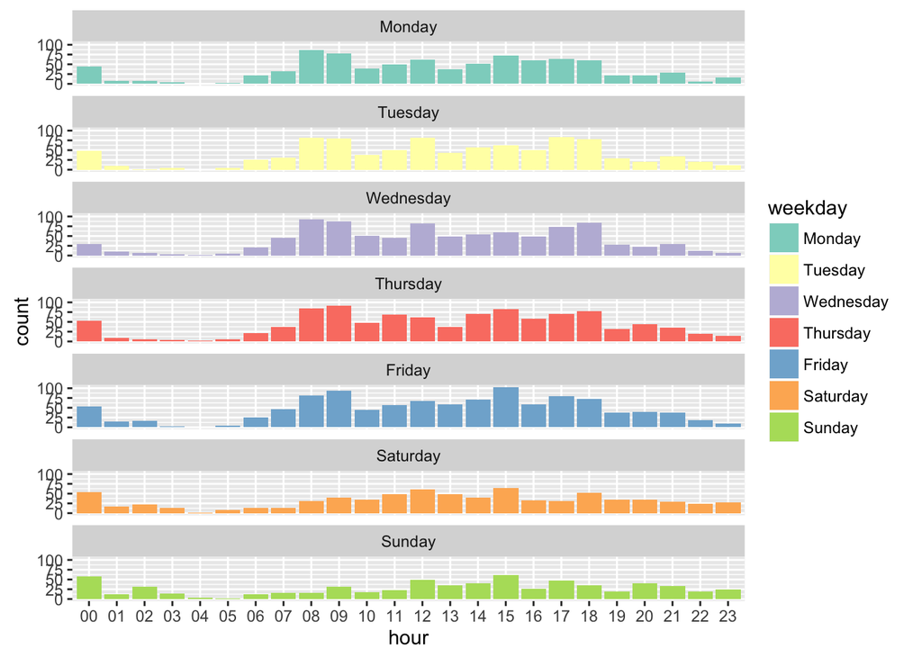

```r
#let's do some analysis by hours and days of the week
#using plyr's groupby, we will get counts for each hour of each day
hour_week <- group_by(df, weekday, hour)
hour_week_crash <- summarize(hour_week, count=n())

#turn the plyer class into a dataframe
df_hour <- data.frame(hour_week_crash)

#use ggplot for some nice visuals
p <- ggplot(data = df_hour, aes(x=hour))
p <- p + geom_bar(aes(weights=count, fill=weekday))
p <- p + scale_fill_brewer(palette="Set3")
p <- p + facet_wrap( ~ weekday, ncol=1)
p
```

As we expected! The weekdays show similar patterns, but there seems to be fewer crashes on the weekends.

Let’s see if we can quantify the likely number of crashes on a given day of the week.

We will have to manipulate the data to a slightly different format to just group it by days. We will also have to fill in the days that there were zero accidents. They do not show up in our data, but 0 is a valid observation for a day.

```r
df_group_days <- group_by(df, days)
df_days <- data.frame(summarize(df_group_days, count=n()))
str(df_days)
```

```
## 'data.frame':    1428 obs. of  2 variables:
##  $ days : chr  "01/01/2010" "01/01/2011" "01/01/2012" "01/01/2013" ...
##  $ count: int  5 8 7 5 3 5 9 3 2 4 ...
```

```r
times <- as.POSIXct(df_days$days, format='%m/%d/%Y')
df_days$dates <- times

#have to create a full dataset and merge it with the crash data
full_days <- seq(as.Date("2010/1/1"), as.Date("2013/12/31"), "days")
df2 <- data.frame(full_days)
#making the df_days column match the df2 column
df_days$dates <- as.Date(substr(df_days$dates, 1, 10))
#merging the two data frames
df_days <- merge(df_days, df2, by.x='dates', by.y='full_days', all.y=TRUE)

#set the NAs to 0
df_days$count[is.na(df_days$count)] <- 0
df_days$weekday <- weekdays(df_days$dates)
```

Let’s do some initial exploratory analysis on the new data frame. It appears that there is a difference depending on the day of the week. The mean is 4.34 crashes per day.

```r
#exploratory analysis on our variable of interest
#count data
#appears to be distributed poisson as expected for count data
table(df_days$count)
```

```
##
##   0   1   2   3   4   5   6   7   8   9  10  11  12  13  14  16  22
##  33 125 184 255 239 215 135 131  67  31  26  10   5   1   2   1   1
```

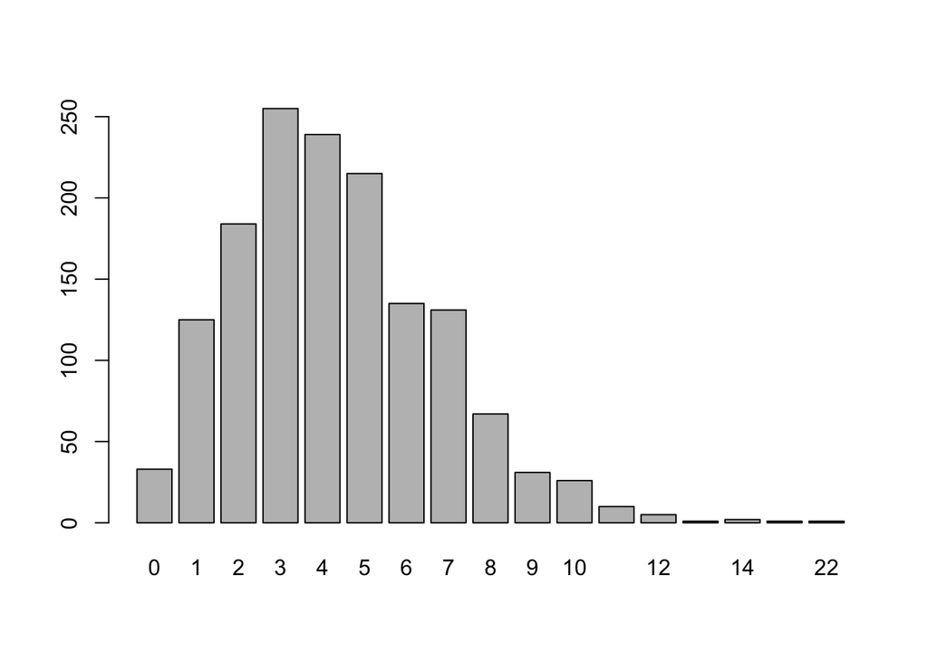

```r
barplot(table(df_days$count))
```

```r
#mean is approximately 4.339 crashes a day, but it does have a high variance
summary(df_days$count)
```

```
##    Min. 1st Qu.  Median    Mean 3rd Qu.    Max.
##   0.000   3.000   4.000   4.339   6.000  22.000
```

```r
var(df_days$count)
```

```
## [1] 5.994254
```

Let’s do a regression to see more about this relationship. We have count data, so we should probably use a poisson. However, our high variances shows that we should use a quasipoisson. This accounts for some of the overdispersion in the model. Let’s analyze this using R’s GLM function.

```r
df_days$weekday <- factor(df_days$weekday)
test <- glm(count ~ weekday, df_days, family=quasipoisson())
summary(test)
```

```
##
## Call:
## glm(formula = count ~ weekday, family = quasipoisson(), data = df_days)
##
## Deviance Residuals:
##     Min       1Q   Median       3Q      Max
## -3.2591  -0.8701  -0.1357   0.6577   5.3998
##
## Coefficients:
##                  Estimate Std. Error t value Pr(>|t|)
## (Intercept)       1.66978    0.03363  49.657  < 2e-16 ***
## weekdayMonday    -0.21641    0.05035  -4.299 1.83e-05 ***
## weekdaySaturday  -0.36963    0.05260  -7.027 3.24e-12 ***
## weekdaySunday    -0.58078    0.05614 -10.345  < 2e-16 ***
## weekdayThursday  -0.07878    0.04858  -1.622 0.105087
## weekdayTuesday   -0.17157    0.04973  -3.450 0.000577 ***
## weekdayWednesday -0.10760    0.04895  -2.198 0.028095 *
## ---
## Signif. codes:  0 '***' 0.001 '**' 0.01 '*' 0.05 '.' 0.1 ' ' 1
##
## (Dispersion parameter for quasipoisson family taken to be 1.255097)
##
##     Null deviance: 2079.7  on 1460  degrees of freedom
## Residual deviance: 1888.5  on 1454  degrees of freedom
## AIC: NA
##
## Number of Fisher Scoring iterations: 5
```

We do have some significance on the factors. However, we should calculate robust standard errors and form some condifence intervals.

```r
#getting robust standard errors
cov.test <- vcovHC(test, type="HC0")
std.err <- sqrt(diag(cov.test))
r.est <- cbind(Estimate= coef(test), "Robust SE" = std.err,
               "Pr(>|z|)" = 2 * pnorm(abs(coef(test)/std.err), lower.tail=FALSE),
               LL = coef(test) - 1.96 * std.err,
               UL = coef(test) + 1.96 * std.err)
r.est
```

```
##                    Estimate  Robust SE     Pr(>|z|)         LL          UL
## (Intercept)       1.6697810 0.03653689 0.000000e+00  1.5981687  1.74139334
## weekdayMonday    -0.2164095 0.05104937 2.242978e-05 -0.3164663 -0.11635275
## weekdaySaturday  -0.3696285 0.05390709 7.043542e-12 -0.4752864 -0.26397059
## weekdaySunday    -0.5807842 0.05794052 1.198057e-23 -0.6943476 -0.46722079
## weekdayThursday  -0.0787813 0.05035142 1.176699e-01 -0.1774701  0.01990748
## weekdayTuesday   -0.1715688 0.05251704 1.087258e-03 -0.2745022 -0.06863537
## weekdayWednesday -0.1075960 0.04951427 2.977804e-02 -0.2046440 -0.01054804
```

But what does does this tell us? We have to take the exponential to determine the actual estimated accidents per day.

In our analysis, Friday was used as the base day. We have to manipulate the data some to get the results in an easy to understand way.

```r
exp(r.est[2:7,4] + r.est[1,4])
```

```
##    weekdayMonday  weekdaySaturday    weekdaySunday  weekdayThursday
##         3.602768         3.073701         2.469020         4.140012
##   weekdayTuesday weekdayWednesday
##         3.757172         4.029026
```

```r
exp(r.est[2:7,5] + r.est[1,5])
```

```
##    weekdayMonday  weekdaySaturday    weekdaySunday  weekdayThursday
##         5.078625         4.381639         3.575741         5.820003
##   weekdayTuesday weekdayWednesday
##         5.326839         5.645424
```

```r
#Friday Data
exp(r.est[1,4])
```

```
## [1] 4.94397
```

```r
exp(r.est[1,5])
```

```
## [1] 5.705287
```

Additional analysis with this data set could try to account for season (perhaps winter has more accidents because road conditions are more hazardous), weather (merge a dataset with weather for Cambridge), or use the GIS data that was in the initial dataset.

This anaylsis was performed with the help of: http://www.ats.ucla.edu/stat/r/dae/poissonreg.htm and http://stackoverflow.com/questions/14818529/plot-histograms-over-factor-variables.